# TUGAS 2

# Scatter Plot close (Y) dengan open (X1)

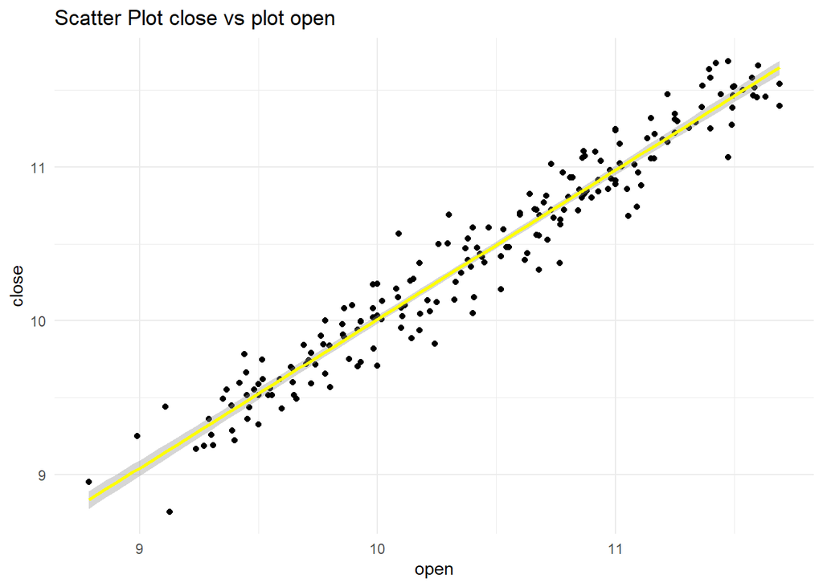

```r
library(ggplot2)
ggplot(data, aes(x = open, y = close)) +
  geom_point(color= "black") +
  geom_smooth(method = "lm", color = "yellow") +
  theme_minimal() +
  labs(x = "open", y = "close",
       title = "Scatter Plot close vs plot open")
```

Berdasarkan scatter plot diatas, menunjukkan hubungan linier yang positif antara close dan open. Artinya, stock close akan meningkat seiring dengan meningkatnya tingkat stock open.

# Scatter Plot close (Y) dengan low (X2)

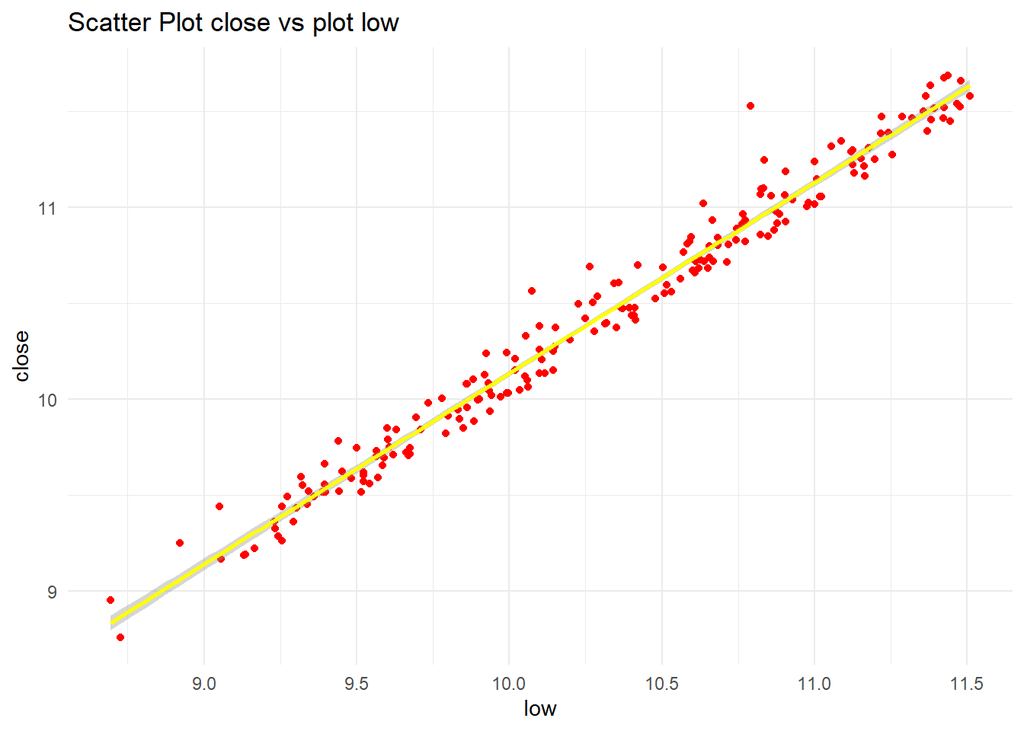

```r
library(ggplot2)
ggplot(data, aes(x = low, y = close)) +
  geom_point(color= "red") +
  geom_smooth(method = "lm", color = "yellow") +
  theme_minimal() +
  labs(x = "low", y = "close",
       title = "Scatter Plot close vs plot low")
```

Berdasarkan scatter plot diatas, menunjukkan hubungan linier yang positif antara close dan low. Artinya, stock close akan meningkat seiring dengan meningkatnya tingkat stock low. Dari plot juga terlihat bahwa titik-titik data cenderung dekat dengan garis linier yang menunjukkan adanya hubungan yang cukup erat antara kedua peubah.